# Task 2: Wild fish catch parameter estimation

Grace Kumaishi

3/2/2021

```r
# Read in the data & tidy:
fish_catch <- read_csv(here("data", "fish_catch.csv")) %>%
  clean_names() %>%
  slice(-(68:71)) %>%
  rename(year = world_wild_fish_catch_and_farmed_fish_production_1950_2012,
         wild_catch = x2,
         farmed_fish = x3,
         total_fish_prod = x4) %>%
  slice(-(1:4)) %>%
  mutate(wild_catch = as.numeric(wild_catch)) %>%
  mutate(farmed_fish = as.numeric(farmed_fish)) %>%
  mutate(total_fish_prod = as.numeric(farmed_fish)) %>%
  mutate(year = as.numeric(year))
```

### 1) Exploratory graph of wild catch over time:

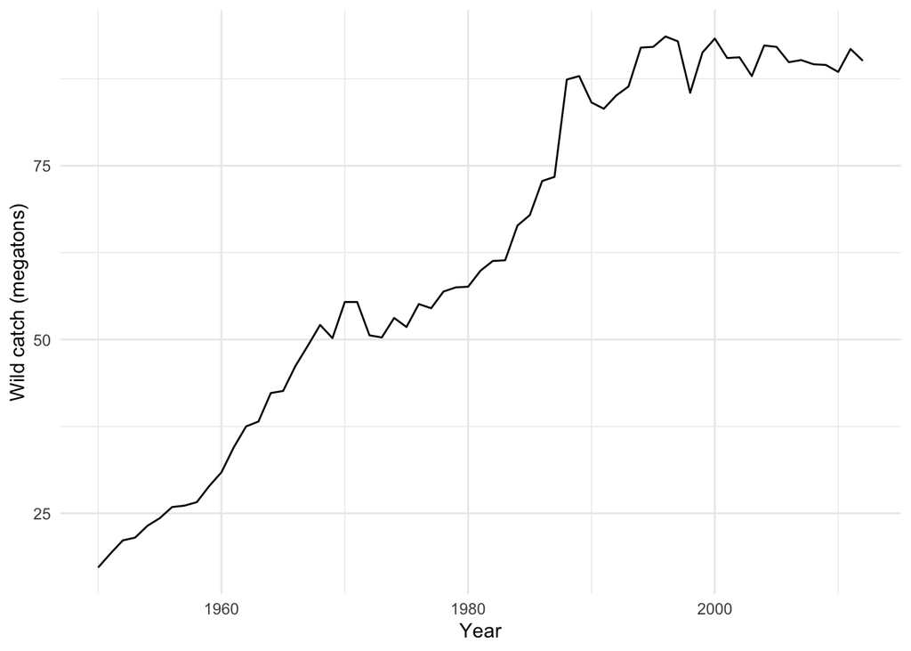

```r
ggplot(data = fish_catch) +
  geom_line(aes(x = year, y = wild_catch)) +
  theme_minimal() +
  labs(x = "Year",
       y = "Wild catch (megatons)")
```

**Visual trends:** This exploratory graph suggests that wild fish catch over time may be following a logistic growth model, which is defined by the equation:

$P(t)=\frac{K}{1+Ae^{-kt}}$

The logistic growth model describes a scenario in which a population approaches a carrying capacity (*K*). *A* is calculated using the equation $\frac{K-P_0}{P_0}$ and *k* is the growth rate constant. We can use this exploratory graph to estimate both the *K* and *A* values. The carrying capacity *K* appears to be approximately **95 megatons**. $P_{0}$ appears to be approximately **17 megatons**. We can estimate *A* by plugging in our estimates of *K* and $P_{0}$ to get a value of **4.6**.

```r
## Find estimate for k:

wild_catch_ln <- ggplot(data = fish_catch) +
  geom_line(aes(x = year, y = log(wild_catch))) +
  theme_minimal() +
  labs(x = "Year",
       y = "ln(Wild catch)")

# Based on the graph of the log-transformed data set, linear growth appears to occur between the onset of the study and 1970, this is what we will use to estimate k.

wild_catch_exp <- fish_catch %>%
  filter(year < 1970) %>%
  mutate(ln_wild_catch = log(wild_catch))

# Model linear to get k estimate:
# lm_k <- lm(ln_wild_catch ~ year, data = wild_catch_exp)
# lm_k

# Coefficient k is ~0.058
```

Based on the graph of the log-transformed data set (output hidden here), linear growth appears to occur between the onset of the study and 1970. This is what we will use to estimate k. Using a linear model, we estimate that the coefficient *k* is about **0.058**.

### 2) Find parameters using nonlinear least squares:

```r
wild_catch <- fish_catch %>%
  select(year, wild_catch) %>%
  mutate(year_new = 0:62) # set 1950 to 0

wild_catch_nls <- nls(wild_catch ~ K/(1 + A*exp(-r*year_new)),
                      data = wild_catch,
                      start = list(K = 95, A = 4.6, r = 0.058),
                      trace = FALSE)

# Look at the model summary:
# summary(wild_catch_nls)

# Use broom:: to show model outputs in a tidier format:
model_wild_catch <- broom::tidy(wild_catch_nls)
```

```r
# Create a table:
model_wild_catch %>%
  gt()
```

| term | estimate | std.error | statistic | p.value |
| --- | --- | --- | --- | --- |
| K | 100.27834049 | 2.734129867 | 36.67651 | 8.568881e-43 |
| A | 4.31633245 | 0.292941380 | 14.73446 | 1.340815e-21 |
| r | 0.06988691 | 0.004648184 | 15.03531 | 5.141906e-22 |

Using the estimated parameters above, we can write our model as:

$$P(t) = \frac{100.3}{1+4.3e^{-0.07t}}$$

### 3) Visualize model output against original data:

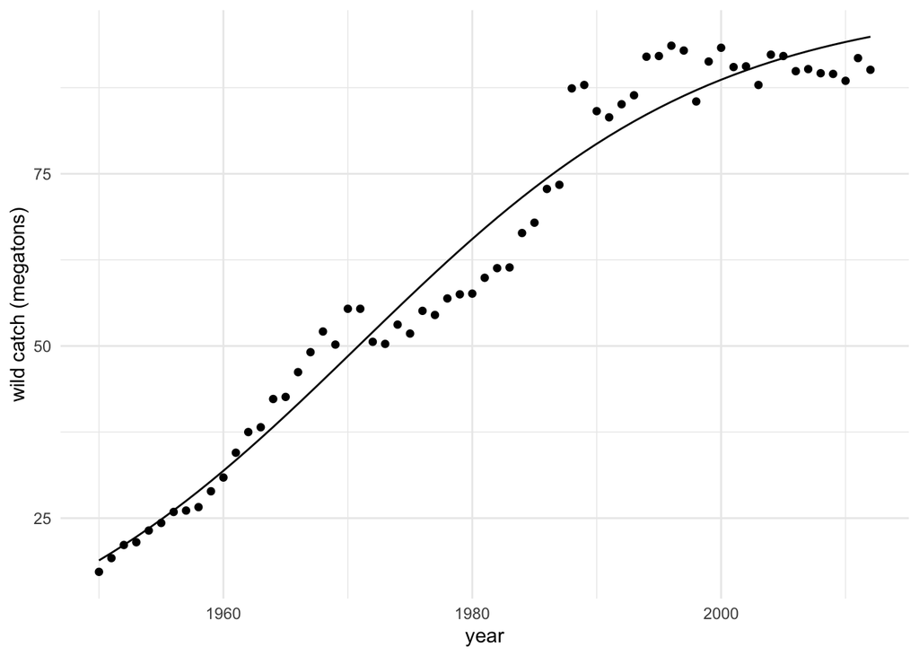

```r
# Make predictions for wild catch over all years of the original data frame:
wild_catch_predict <- predict(wild_catch_nls)

# Bind those predictions to the original data:
wild_catch_complete <- data.frame(wild_catch, wild_catch_predict)

# Plot them together:
ggplot(data = wild_catch_complete, aes(x = year, y = wild_catch)) +
  geom_point() +
  geom_line(aes(x = year, y = wild_catch_predict)) +
  theme_minimal() +
  labs(x = "year",
       y = "wild catch (megatons)")
```

### Citation:

[Global wild fish catch and aquaculture production, compiled by Earth Policy Institute with 1950-2010 from U.N. Food and Agriculture Organization (FAO), Global Capture Production and Global Aquaculture Production, electronic databases, at www.fao.org/fishery/topic/16140/en.](https://drive.google.com/file/d/1sKjDqxbpWD7vd7Kt4tBNpl6pHEf_LnIe/view)